# RFlux package v3.2.0

The RFlux package provides an R graphical user interface for processing eddy covariance (EC) raw data.

RFlux has been developed in the context of the Integrated Carbon Observation System European Research Infrastructure - Ecosystem Thematic Center (ICOS-ETC http://www.icos-etc.eu/icos/) and has been supported by the EU H2020 ENVRI PLUS (grant no. 654182), RINGO (grant no. 730944) and ENVRI-FAIR (grant no. 824068) research projects.

RFlux can be downloaded at https://github.com/icos-etc/RFlux by running the following code:

```r
install.packages("devtools")
devtools::install_github("icosetc/RFlux")
```

```r
suppressMessages(library(RFlux))
help(package=RFlux)
citation("RFlux")
```

```
#>
#>   Domenico Vitale, Dario Papale and ICOS-ETC Team (2022). RFlux: An R
#>   Package for Processing and Cleaning Eddy Covariance Flux
#>   Measurements. R package version 3.2.0.
#>
#> A BibTeX entry for LaTeX users is
#>
#>   @Manual{,
#>     title = {{RFlux}: An R Package for Processing and Cleaning Eddy Covariance Flux Measurements},
#>     author = {Domenico Vitale and Dario Papale and {ICOS-ETC Team}},
#>     organization = {ICOS-ETC},
#>     address = {Viterbo, Italy},
#>     year = {2022},
#>     note = {R package version 3.2.0},
#>     url = {https://github.com/icos-etc/RFlux},
#>   }
```

The main functionalities implemented in the RFlux package are:

- raw data and metadata management
- fluxes and other micrometorological varabile estimation
- data cleaning

In the following a description of them is provided.

# Raw data and metadata management

RFlux requires raw data be in a specific format, such as that for RFlux *closed_path_rawdata* data frame:

```r
data(closed_path_rawdata)
str(closed_path_rawdata)
```

```
#> Classes 'data.table' and 'data.frame':   36000 obs. of  12 variables:
#>  $ U         : num  -0.584 -0.648 -0.49 -0.81 -1.102 ...
#>  $ V         : num  2.5 2.52 2.45 2.42 2.28 ...
#>  $ W         : num  -0.0499 -0.0239 0.0119 -0.0161 0.0066 ...
#>  $ T_SONIC   : num  303 303 303 303 303 ...
#>  $ CO2       : num  349 349 349 349 349 ...
#>  $ H2O       : num  16.5 16.5 16.5 16.5 16.5 ...
#>  $ SA_DIAG   : int  1 2 3 4 5 6 7 8 9 10 ...
#>  $ GA_DIAG   : int  8191 8191 8191 8191 8191 8191 8191 8191 8191 8191 ...
#>  $ T_CELL    : num  29.2 29.1 29.2 29.1 29.1 ...
#>  $ T_CELL_IN : num  31.3 31.3 31.3 31.3 31.3 ...
#>  $ T_CELL_OUT: num  28.6 28.6 28.6 28.6 28.6 ...
#>  $ PRESS_CELL: num  96.9 96.9 96.9 96.9 96.9 ...
#>  - attr(*, ".internal.selfref")=<externalptr>
```

If needed, a generic ASCII file can be converted in a format suitable for RFlux by means of the RFlux *convert_rawdata* function (see the help page for more details).

Eddy covariance raw data sampled by either open- or closed-path system can be ingested in RFlux. If some variable is not available (eg T_CELL in open-path system), then it will be considered as missing (-9999).

Eddy covariance metadata (ecmd) need to be organized in a *.csv* file containing informations as those reported in the RFlux *ecmd_table* data frame:

```r
data(ecmd_table)
str(ecmd_table)
```

```
#> Classes 'data.table' and 'data.frame':   5 obs. of  52 variables:
#>  $ DATE_OF_VARIATION_DB     :integer64 20180614 201809191219 201908162000 201906171100 201908161600
#>  $ DATE_OF_VARIATION_EF     :integer64 201805290030 20180614 20181026 201904101300 201908140835
#>  $ SITEID                   : chr  "DE-HoH" "DE-HoH" "DE-HoH" "DE-HoH" ...
#>  $ LATITUDE                 : num  52.1 52.1 52.1 52.1 52.1
#>  $ LONGITUDE                : num  11.2 11.2 11.2 11.2 11.2
#>  $ ALTITUDE                 : int  193 193 193 193 193
#>  $ CANOPY_HEIGHT            : num  33.2 33.3 33.3 33.3 33.3
#>  $ SA_MANUFACTURER          : chr  "gill" "gill" "gill" "gill" ...
#>  $ SA_MODEL                 : chr  "hs_50_1" "hs_50_1" "hs_50_1" "hs_50_1" ...
#>  $ SA_SW_VERSION            : logi  NA NA NA NA NA
#>  $ SA_WIND_DATA_FORMAT      : chr  "uvw" "uvw" "uvw" "uvw" ...
#>  $ SA_NORTH_ALIGNEMENT      : chr  "spar" "spar" "spar" "spar" ...
#>  $ SA_HEIGHT                : int  49 49 45 45 45
#>  $ SA_NORTH_OFFSET          : int  235 235 235 235 235
```

[output cut: 39 more lines]

# Fluxes estimation

Fluxes and other micrometeorolgical parameters estimation is performed through a call to the open source EddyPro (registered trademark, LI-COR, Biosciences) software (Fratini and Mauder, 2014) Note that it is required the EddyPro software is installed on your system (for download see https://www.licor.com/EddyPro).

Instructions for metadata (ie the *.metadata* and *dynamic_metadata.txt* files) and processing options (ie *.eddypro* files) can be created by means of the RFlux *get_md* function.

```r
workdir <- getwd()
siteID <- "DE-HoH"
PATH_ECMD <- system.file("extdata", "DE-HoH_ecmd.csv", package = "RFlux")
PATH_RAWDATA <- system.file("extdata", package = "RFlux")
PATH_OUTPUT <- paste0(workdir, "/eddypro/processing")
PATH_SA_FILE <- system.file("extdata", "spectral_assessment.txt", package = "RFlux")
PATH_PF_FILE <- system.file("extdata", "planar_fit.txt", package = "RFlux")

MD <- get_md(path_ecmd=PATH_ECMD,
             path_rawdata=PATH_RAWDATA,
             path_output=PATH_OUTPUT,
             online=TRUE,
             path_sa_file=PATH_SA_FILE,
             path_pf_file=PATH_PF_FILE,
             tlag_meth=2, ## Maximum Covariance with Default
             despike_meth="VM97", ## Vickers and Mahrt (1997)
             detrend_meth="BA", ## Block Average
             tilt_correction_meth="PF") ## Planar Fit
```

Once created the input files for EddyPro software, the raw data processing can be performed as follows:

```r
PATH_EDDYPRO_BIN <- "/Applications/eddypro.app/Contents/MacOS/bin" ## put your path here!
PATH_EDDYPRO_PROJ <- PATH_OUTPUT
eddypro_run(siteID="DE-HoH",
            path_eddypro_bin=PATH_EDDYPRO_BIN,
            path_eddypro_projfiles=PATH_EDDYPRO_PROJ,
            showLOG=FALSE)
```

```
#>
#>  The results of EddyPro run are stored in /Users/mac/RFlux_library/RFlux/vignettes/eddypro/processing
```

# Data cleaning

Quality control involves the data cleaning procedure described in Vitale et al (2020) and summarized in Figure 1.

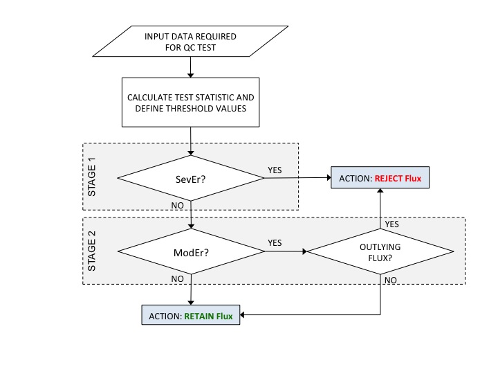

**Figure 1**. Schematic summary of the proposed data cleaning procedure. SevEr and ModEr indicating strong and moderate evidence about the presence of a specific source of systematic error, respectively.

The RFlux implementation of the data cleaning procedure involves a three-step procedure.

- Step 1: Estimation of the QC test statistics via the RFLux *qcStat* function (see below for more details about the qc tests)

```r
PATH_RAWDATA <- system.file("extdata", "DE-HoH_EC_201907301200_v01.csv", package = "RFlux")
QC_STAT <- qcStat(path_rawdata=PATH_RAWDATA, ext_tstamp="END", path_output=NULL, FileName=NULL)
```

- Step 2: Generating the workset via the RFlux *ecworkset* function (ie merging the EddyPro outputs with the QC test statistics and build a multivariate time series with regular timestamp).

```r
PATH_EPOUT <- system.file("extdata", "eddypro_DE-HoH_full_output_example.csv", package = "RFlux")
PATH_EPQC <- system.file("extdata", "eddypro_DE-HoH_qc_details_example.csv", package = "RFlux")
PATH_EPMD <- system.file("extdata", "eddypro_DE-HoH_metadata_example.csv", package = "RFlux")
PATH_QCSTAT <- system.file("extdata", "qcStat_example.csv", package = "RFlux")

WorkSet <- ecworkset(path_EPout=PATH_EPOUT,
                     path_EPqc=PATH_EPQC,
                     path_EPmd=PATH_EPMD,
                     path_QCstat=PATH_QCSTAT,
                     path_output=NULL,FileName=NULL)
str(WorkSet)
```

```
#> 'data.frame':    1 obs. of  143 variables:
#>  $ TIMESTAMP            : Factor w/ 1 level "201907301130": 1
#>  $ DNtime               : num 1
#>  $ file_records         : num 36000
#>  $ used_records         : num 36000
#>  $ Stability            : num -0.169
#>  $ Tau                  : num -0.707
#>  $ qcTau                : num 0
#>  $ ruTau                : num 0.121
#>  $ H                    : num 317
#>  $ qcH                  : num 0
#>  $ ruH                  : num 44.3
#>  $ LE                   : num 233
#>  $ qcLE                 : num 0
#>  $ ruLE                 : num 31.8
```

[output cut: 86 more lines]

- Step 3: Application of the data cleaning procedure (including despiking) via the *cleanFlux* function (see Figure 2).

```r
PATH_WORKSET <- system.file("extdata", "ecworkset_example.csv", package = "RFlux")
PATH_ECMD <- system.file("extdata", "DE-HoH_ecmd.csv", package = "RFlux")

cleanset <- cleanFlux(path_workset=PATH_WORKSET,
                      path_ecmd=PATH_ECMD,
                      path_output=NULL,
                      FileName=NULL,
                      plotQC=FALSE,
                      storage=TRUE)
str(cleanset)
```

```
#> 'data.frame':    1344 obs. of  187 variables:
#>  $ TIMESTAMP_START          : num  2.02e+11 2.02e+11 2.02e+11 2.02e+11 2.02e+11 ...
#>  $ TIMESTAMP_END            : num  2.02e+11 2.02e+11 2.02e+11 2.02e+11 2.02e+11 ...
#>  $ TAU_UNCLEANED            : num  -4.15 -2.42 -4.99 -3.76 -2.97 ...
#>  $ TAU                      : num  -4.15 -2.42 -4.99 -3.76 -2.97 ...
#>  $ TAU_DATA_FLAG            : num  0 0 0 0 0 2 0 0 0 0 ...
#>  $ H_UNCLEANED              : num  -31.8 -26.4 -12.7 -27.4 -21.5 ...
#>  $ H                        : num  -31.8 -26.4 -12.7 -27.4 -21.5 ...
#>  $ H_DATA_FLAG              : num  0 0 0 0 0 0 0 0 0 0 ...
#>  $ LE_UNCLEANED             : num  54.1 31.9 31.8 32.6 15.7 ...
#>  $ LE                       : num  54.1 31.9 31.8 32.6 15.7 ...
#>  $ LE_DATA_FLAG             : num  0 0 0 0 0 0 2 0 2 0 ...
#>  $ FC                       : num  8.09 6.88 4.75 7.71 5.63 ...
#>  $ SC                       : num  NA -0.557 1.751 2.345 -1.8 ...
#>  $ NEE_UNCLEANED            : num  NA 6.32 6.5 10.05 3.83 ...
```

[output cut: 86 more lines]

By specifying *plotQC=TRUE* in the *cleanFlux* function, a synthesis of the data cleaning, as showed in Figure 2, will be also reported.

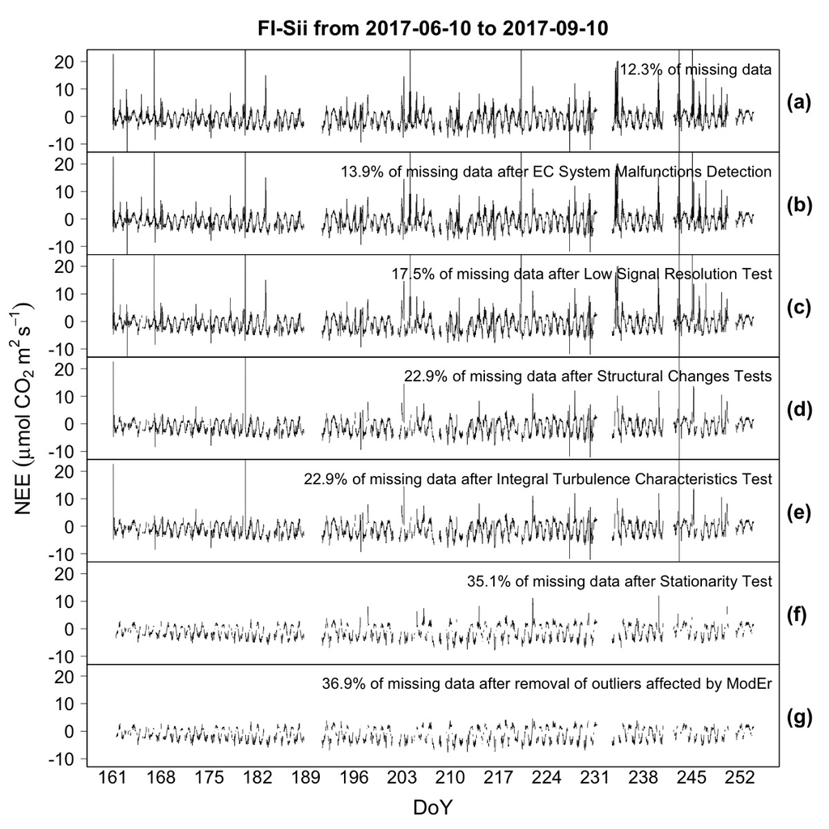

**Figure 2.** An application of the data cleaning procedure

## QC tests

The set of quality control tests implemented in RFlux is summarized in Table 1.

**Table 1.** Quality control tests implemented in RFlux.

[output not shown]

$^a$ Each test is implemented in the RFlux package starting from the version indicated

$^b$ *hz* is the acquisition frequency (ie 10 or 20)

$^c$ units refer to $\mu molm^{-2}s^{-1}$ for NEE, $Wm^{-2}$ for H, LE, $m^2s^{-2}$ for TAU

### Detail of QC tests

#### FMR - Fraction of missing records

The fraction of missing records (FMR) is calculated by considering the missing data affecting time series involved in the covariance estimation. The criteria used to assign a statement are as follows:

- SevEr: FMR > 15$\%$
- ModEr: 5$\%$ < FMR $\le$ 15
- NoEr: FMR $le$ 5$\%$

#### LGD - Longest gap duration

The longest gap duration (LGD) is calculated by considering the longest sequence of consecutive missing data affecting time series involved in covariance estimation. The criteria used to assign a statement are as follows:

- SevEr: LGD > 180 sec
- ModEr: 90 sec < LGD $\le$ 180 sec
- NoEr: LGD $\le$ 90 sec

#### LSR - Low-Signal resolution

High-frequency EC raw data can be affected by low-signal-resolution problems. Resolution problems are mainly caused by a limited digitalization of the signal during data acquisition, when signal fluctuations approach the resolution of the instruments. This kind of problem causes a step ladder in the distribution of sampled data, and time series are characterized by the presence of repeated contiguous values. Instrumental faults can lead to a time series that remains fixed at a constant value for a period of time (dropout), analogously introducing artificial repeated values, though with a very different pattern of repetition. Repeated values are always to be considered an artefact since even in the (unlikely) event of a signal maintaining a constant value for an extended period of time, its measured values would still vary on account of the random error. In this particular scenario, contiguous repeated values would not actually lead to a bias in the flux estimate, because neglecting the presence of random error does not affect covariance estimates. Instead when repeated values do not reflect the true dynamic of the underlying signal, they can lead to a significant bias in flux estimates. The LSR test aims at disentangling these two situations. The test consists of evaluating the discrepancy between the w-scalar cross-correlation functions (CCFs) of the original time series and of the time series after removal of repeated values. If the discrepancy is negligible then the effect of repeated values on the covariance estimate is considered irrelevant. This could occur in the case of a small number of repeated data or if their values are still representative of the underlying signal dynamic. Conversely, when a significant discrepancy is found, the covariance estimate is considered biased. The significance of such a discrepancy is evaluated by means of the coefficient of determination ($R^2$) of the linear regression through the origin of the CCFs estimated at short lags (±25 steps). The criteria used to assign a statement are as follows:

- SevEr if $R^2$ < 0.990
- ModEr if 0.990 $\leq R^2 \leq$ 0.995
- NoEr if $R^2$ > 0.995

#### HFx, HDx - Homogeneity of fluctuations, differenced data

EC time series can be subject to regime changes such as sudden shifts in the mean and/or in the variance. In some circumstances, those are imputable to natural causes as in cases of intermittent turbulence (Sandborn, 1959) and wind pattern change over a heterogeneous or anisotropic footprint. In other cases, such changes are artefacts generated by instrumental malfunctions. Aberrant structural changes in mean and/or variance lead to violation of the assumption of stationarity underlying the EC method. They should therefore be treated as sources of systematic errors. To identify such situations two tests are implemented, whose rejection rules are based on objective criteria but which, notably, do not discern natural changes from measurement artefacts. The HF tests takes into consideration the homogeneity of the distribution of fluctuations ($y_t' = y_t - \bar{y}$, where $\bar{y}$ is the mean level estimated according to the averaging rule adopted in the covariance calculation, e.g. block average or linear detrending). The HD test makes use of the same rule, but it evaluates the homogeneity of the distribution of first-order differenced data, $\Delta y_t = y_t - y_{t-1}$. Both tests aims at evaluating the percentage of data in the tails with respect to the bounds imposed by Chebyshev’s inequality theorem. When the inequality is violated, it is a symptom of data inhomogeneity due changes in the mean level (HF test) or changes in variance (HD test). Based on the upper bounds imposed by Chebyshev’s inequality for 5$\sigma$ and 10$\sigma$, the following criteria be applied:

- SevEr, if HF$_5>4\%$, HD$_5>4\%$, HF$_{10} >1\%$ or HD$_{10}>1\%$ (i.e. more than 4$\%$ of fluctuations or differenced values are beyond the ±5$\sigma$ limits or more than 1$\%$ of them are beyond the ±10$\sigma$ limits);
- ModEr, if $2\%<HF5\leq4\%$, $2\%<HD5\leq4\%$, $0.5\%<HF10\leq1\%$ or $0.5\%<HD10\leq1\%$ (i.e. more than 2$\%$ of fluctuations or differenced values are beyond the ±5$\sigma$ limits or more than 0.5$\%$ of them are beyond the ±10$\sigma$ limits);
- NoEr, if HF$_5\leq 2\%$, HD$_5\leq 2\%$, HF$_{10}\leq 0.5\%$ and HD${10}\leq 0.5\%$ (i.e. fewer than 2$\%$ of both fluctuations and differences are beyond the ±5$\sigma$ limits and fewer than 0.5$\%$ of them are beyond the ±10$\sigma$ limits).

As a robust estimate of $\sigma$, we used the Rousseeuw and Croux (1993) Qn estimator corresponding approximately to the first quartile of the sorted pairwise absolute differences. Compared to other robust scale estimators – such as the median absolute deviation about the median (MAD) and the interquartile distance (IQD) – it is a location-free estimator; i.e. it does not implicitly rely on a symmetric noise distribution. Similar to MAD, its breakdown point is 50$\%$; i.e. it becomes biased when 50$\%$ or more of the data are large outliers. However, its efficiency is larger, especially when identical measurements occur, e.g. due to low-signal-resolution problems.

#### KID - Kurtosis index on the differenced data

The KID test consists of evaluating the kurtosis index on the differenced data $\Delta y_t$. The kurtosis index is defined by the standardized fourth moment of the variable about the mean. Because variations about the mean are raised to the power of 4, the kurtosis index is sensitive to tail values of the distribution and can therefore be used to characterize them (Westfall, 2014). Since the tails of a distribution represent events outside the “normal” range, a higher kurtosis means that more of the variance is contributed by infrequent extreme observations (i.e. anomalies) as opposed to frequent, modestly sized deviations. The sensitivity to tail values and the application to differentiated values make the KID a very useful tool to detect a range of instrumental problems, which include abnormal changes in mean, variance, but also the presence of undetected residual spikes and drop-out events (in these situations differenced time series will show a spike in correspondence of each change point). To eliminate the sensitivity of the KID to the presence of repeated values (which become zeros in the differenced variable), such values are not included in KID estimation. Bearing in mind that the kurtosis index for a Gaussian and a Laplace PDF is equal to 3 and 6, respectively, we choose reasonably large threshold values to make sure we select only time series characterized by heavy-tailed distribution as is the case of data contaminated by extreme events representative of the aforementioned problems. Namely, the criteria used to assign a statement are as follows::

- SevEr if KID > 50
- ModEr if 30 < KID$\leq$ 50
- NoEr if KID $\leq$ 30

#### ITC - Integral Turbulence Characteristics

One of the assumptions underlying the EC method is the occurrence of well-developed turbulence conditions. A widely used test to assess the quality of the turbulence regime is the integral turbulence characteristics (ITC) test proposed by Foken and Wichura (1996). The criteria adopted to assign SevEr, ModEr and NoEr statements are based on threshold values proposed by Mauder and Foken (2004, Table 16). In particular, the criteria used to assign a statement are as follows:

- SevEr if ITC > 100
- ModEr if 30 < ITC $\leq$ 100
- NoEr if ITC $\leq$ 30

#### M98 - Stationary Test

The working equation of turbulent fluxes as the (appropriately scaled) w-scalar covariance is based on a simplification of the mass conservation equation (see e.g. Foken et al., 2012a). One of the assumptions behind such simplification is that of stationary conditions, which are however not always fulfilled during the measurement period. Diurnal trends, changes in meteorological conditions (e.g. passage of clouds), boundary layer transitions, large-scale variability and changes in footprint areas are only some example of sources generating non-stationary conditions. In the presence of non-stationarity, flux estimates are biased. The magnitude and sign of the systematic error depend on the nature of the non-stationarity, on the proportion of total variability explained by trend components and on the way (deterministic or stochastic) independent trend components interact with each other. The non-stationarity ratio test proposed by Mahrt (1998) was selected for this task with threshold values as proposed by Vitale et al (2020). In particular, the criteria used to assign a statement are as follows:

- SevEr if M98 > 3
- ModEr if 2 < M98 $\leq$ 3
- NoEr if M98 $\leq$ 2

### AL1 - Test based on the autocorrelation estimate at lag 1

The AL1 test is based on the estimation of autocorrelation at lag 1. EC raw data time series sampled at ultra-high frequency (e.g. 10, 20 Hz) are characterized by a high degree of serial dependence (see Figure 1S in Vitale et al, 2020). In particular, the autocorrelation estimates at lag 1 is expected to be larger than 0.90 for all EC rawdata variables. A low value of the lag-1 correlation estimate implies the presence of a noisy signal ie, a situation in which the noise component predominates over that of the signal underlying the sampled data. Bearing in mind the characteristics of the variables involved, as mentioned earlier, such a situation constitutes a symptom of the presence of a source of systematic error. Causes can be attributed to instrumental problems and/or logger errors during data aquisition. The criteria used to assign a statement are as follows:

- SevEr if AL1 $\leq$ 0.5
- ModEr if 0.5 < AL1 $ 0.75
- NoEr if AL1 > 0.75

#### DDI - Data Distribution Integrity

This test aims to identify those situations in which the sampled data tend to concentrate around a few values. These situations can occur not only in the presence of repeated consecutive values, but also in cases where the series exhibits a reduced variability. The identification of these issues is conducted by dividing the data into bins, then identifying the maximum frequency (the maximum number of observations that fall into a bin). The optimal width of the bins (h) is set following the Freedman-Diaconis rule which is designed roughly to minimize the integral of the squared difference between the histogram (i.e., relative frequency density) and the density of the theoretical probability distribution. In particular, h = 2 $\cdot$ IQR $\cdot$ n$^{-1/3}$ and number of bins equal to (max-min)/h where n is the number of observations, max and min are the maximum and the minimum value, respectively. The criteria used to assign a statement are as follows:

- SevEr if DDI > hz $\cdot$ 300
- ModEr if DDI $\le$ hz $\cdot$ 300
- NoEr if DDI $\le$ hz $\cdot$ 150

As an example, for a variable sampled in 30-min time period at 10Hz acquisition frequency, an instrumental issue with SevEr flag is detected when more than 3000 values fall in a bin. Note that in case of 18000 data drawn from a normal and a laplace distribution the maximum number of values falling in a bin (ie the peak since they are symmetrical around the mean) is about 750 and 900, respectively. Therefore, flagged EC rawdata have a leptokurtic distribution with a far higher peak (very thin bell) than that of most common statistical distributions.

#### DIP - Test of unimodality

Flux estimation by means of EC technique requires steady-state conditions. Under stationary conditions time series have a constant mean. This implies unimodal distributions. Testing for the presence of multimodal distributions can therefore make it easier to find possible errors in rawdata. For example may indicate the presence of structural breaks (e.g., abrupt jumps) or sine wave patterns that violate basic assumptions underlying the EC technique. To test unimodality, the Hartingans’ DIP test is performed. The criteria used to assign a statement are based on the p-value associated to the test statistic and are as follows:

- SevEr if DIP < 0.05
- ModEr if 0.05 $\le$ DIP $\le$ 0.1
- NoEr if DIP > 0.1

Figures 3 and 4 show two illustrative examples of applications of HFx, HDx, KID, AL1, DDI and DIP tests described previously. These figures are obtained by specyfing the option plot=TRUE in the RFLux *inst_prob_test* function (see the help page for more details).

In particular, Figure 3 shows an application of the QC tests on a 30-min vertical wind speed variable where the signal is contaminated by a large amount of noise that dominates the underlying signal. Assuming that the true signal should have a high degree of serial dependence, a low correlation at lag 1 as detected by the AL1 test is a symptom of the presence of a source of systematic error.

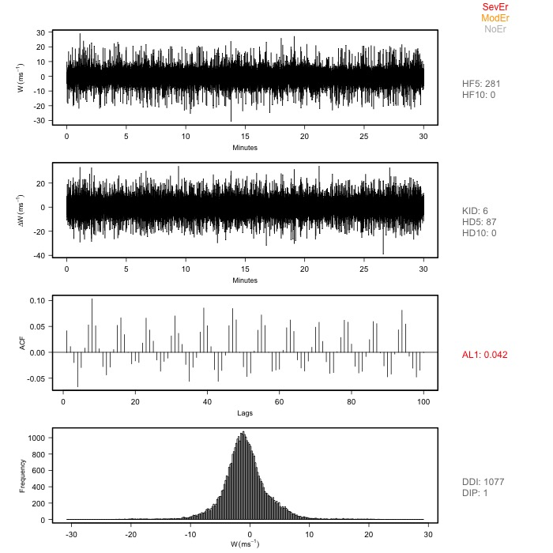

**Figure 3**. Graphical output of the *inst_prob_test* function.

Figure 4, instead, shows an application of the QC tests on a 30-min CO2 variable subject to a sudden shift in the mean level. Such structural change is detected by HF5 (ModEr flag), KID (SevEr flag), DDI (SevEr flag) and DIP (SevEr flag) tests.

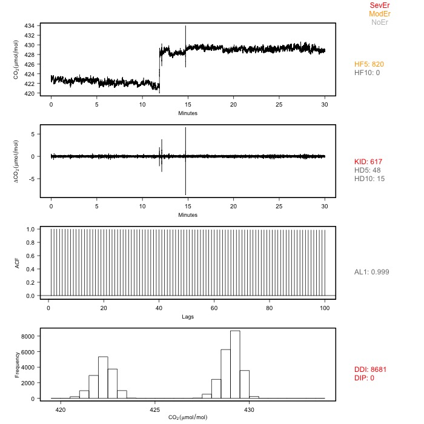

## References

Foken T, Aubinet M, Leuning R (2012). The Eddy Covariance Method, in: Eddy Covariance, 1–19, Springer Netherlands, Dordrecht, doi: https://doi.org/10.1007/978-94-007-2351-1_1.

Foken T, Wichura B (1996). Tools for quality assessment of surface-based flux measurements, Agr. Forest Meteorol., 78, 83–105, https://doi.org/10.1016/0168-1923(95)02248-1.

Fratini G and Mauder M (2014). Towards a consistent eddy-covariance processing: an intercomparison of EddyPro and TK3, Atmos. Meas. Tech., 7, 2273–2281, https://doi.org/10.5194/amt-7-2273-2014.

Freedman D, Diaconis P (1981). On the histogram as a density estimator: L_2 theory. Zeitschrift für Wahrscheinlichkeitstheorie und verwandte Gebiete, 57, 453–476. doi: https://doi.org/10.1007/BF01025868.

Hartigan JA, and Hartigan PM (1985). The Dip Test of Unimodality; Annals of Statistics 13, 70–84.

LI-COR Biosciences: EddyPro 7.0.4: Help and User’s Guide, LI-COR Biosciences, Lincoln, Nebraska USA, https://www.licor.com/EddyPro, 2020.

Mahrt L (1998), Flux sampling errors for aircraft and towers, J. Atmos. Ocean. Tech., 15, 416–429, doi: https://doi.org/10.1175/1520-0426(1998)015<0416:fsefaa>2.0.co;2.

Mauder M and Foken T (2004). Documentation and instruction manual of the Eddy Covariance software package TK2, Univ Bayreuth, Abt Mikrometeorol, 26–42, available at: https://epub.uni-bayreuth.de/884/1/ARBERG026.pdf.

Rousseeuw PJ and Croux C (1993). Alternatives to the Median Absolute Deviation, J. Am. Stat. Assoc., 88, 1273–1283, doi: https://doi.org/10.1080/01621459.1993.10476408.

Vitale D, Fratini G, Bilancia M, Nicolini G, Sabbatini S, Papale D (2020) A robust data cleaning procedure for eddy covariance flux measurements, Biogeosciences, 17, 1367–1391, doi: https://doi.org/10.5194/bg-17-1367-2020.

Westfall, P. H.: Kurtosis as Peakedness, 1905– 2014. R.I.P., Am. Stat., 68, 191–195, https://doi.org/10.1080/00031305.2014.917055, 2014.